# GITHUB:- https://github.com/ARBINDA765/Handling-Missing-Values

## All the techniques of handling ,missing values

> 1-Mean/ Median/Mode replacement

> 2-Random Sample Imputation

> 3-Capturing NAN values with a new feature

> 4-End of Distribution imputation

> 5-Arbitrary imputation

> 6-Frequent categories imputation

# The data imputation purely depends on the datatype.

1. The imputation method should be decided after considering the distribution of data:normal distribution and skewed distribution (be it right-skewed or left-skewed). 2. Mean imputation works better if the distribution is normally-distributed or has a Gaussian distribution, while median imputation is preferable for skewed distribution(be it right or left) >3. If the datatype of the column is numerical then replace the values with Mean in case of Normal distribution and >4. Median imputatation in case of Skewed distribution. >5. If the datatype of the column is Categorical then the Mode Imputation method is the appropriate method.

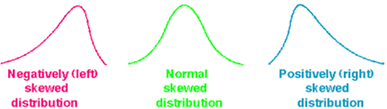

# 2-Random Sample Imputation

Aim:

1. Random sample imputation consists of taking random observation from the dataset and we use this observation to replace the nan values
2. Random Sample Imputation take a random observation from the feature.
3. After that we use random observation to replace NaN in that feature.

When should it be used?

> It assumes that the data are missing completely at random(MCAR)

```python
import pandas as pd
df=pd.read_csv('titanic.csv', usecols=['Age','Fare','Survived'])
df.head()
```

|  | Survived | Age | Fare |
| --- | --- | --- | --- |
| 0 | 0 | 22.0 | 7.2500 |
| 1 | 1 | 38.0 | 71.2833 |
| 2 | 1 | 26.0 | 7.9250 |
| 3 | 1 | 35.0 | 53.1000 |
| 4 | 0 | 35.0 | 8.0500 |

```python
#Checking the null values
df.isnull().sum()
```

```
Survived      0
Age         177
Fare          0
dtype: int64
```

```python
#% OF NULL values
df.isnull().mean()*100
```

```
Survived     0.00000
Age         19.86532
Fare         0.00000
dtype: float64
```

```python
#No of records are having null
df['Age'].isnull().sum()
```

```
177
```

```python
#DataFrame.sample(n=None, frac=None, replace=False, weights=None, random_state=None, axis=None, ignore_index=False)[source]¶
#Return a random sample of items from an axis of object.

df['Age'].sample(n=df['Age'].isnull().sum(),random_state=0)
```

```
495     NaN
648     NaN
278     7.0
31      NaN
255    29.0
       ...
425     NaN
760     NaN
780    13.0
837     NaN
215    31.0
Name: Age, Length: 177, dtype: float64
```

```python
#- where .dropna() function drop all nan values in that feature
#- This function check where is null values are present and replace Nan with random sample
# We use random_state because it replace NaN with specific value only ( if we not use random_state then values change evrytime when we run .
df['Age'].dropna().sample(df['Age'].isnull().sum(),random_state=0)
```

```
423    28.00
177    50.00
305     0.92
292    36.00
889    26.00
       ...
539    22.00
267    25.00
352    15.00
99     34.00
689    15.00
Name: Age, Length: 177, dtype: float64
```

```python
df['Age'].isnull().head(6)
```

```
0    False
1    False
2    False
3    False
4    False
5     True
Name: Age, dtype: bool
```

```python
#Finding the index where the value is null
df[df['Age'].isnull()].index
```

```
Int64Index([  5,  17,  19,  26,  28,  29,  31,  32,  36,  42,
            ...
            832, 837, 839, 846, 849, 859, 863, 868, 878, 888],
           dtype='int64', length=177)
```

```python
#Create A function which Replace NaN with Random Sample
#Here we creating a two new features Age_median and Age_random,Age_Mean
#In Age_median replace NaN with Median and In Age_random replce NaN with Random Sample

def impute_nan(df,variable,median):
    df[variable+"_median"]=df[variable].fillna(median) #replace Nan with median,Fillna (will fill na value with the defined value)
    df[variable+'_mean']  = df[variable].fillna(df[variable].mean())
    df[variable+"_random"]=df[variable]##Copy feature into new feature

#calculate random sample and store into random_sample
##It will have the random sample to fill the nan value
#in random_sample all filled nan values are present now we want to put/merge this all filled values in our dataset
# for this we want to match all nan values index in random_sample with df[variable_'random]

    random_sample=df[variable].dropna().sample(n=df[variable].isnull().sum(),random_state=0)
    ##pandas need to have same index in order to merge the dataset
    random_sample.index=df[df[variable].isnull()].index
    df.loc[df[variable].isnull(),variable+'_random']=random_sample
```

# loc is label based and allowed inputs are:

> A single label 'A' or 2 (Note that 2 is interpreted as a label of the index.)

> A list of labels ['A', 'B', 'C'] or [1, 2, 3] (Note that 1, 2, 3 are interpreted as labels of the index.)

> A slice with labels 'A':'C' (Both are included)

> Conditions, a boolean Series or a boolean array

> A callable function with one argument

# iloc is integer position based and allowed inputs are:

> An integer e.g. 2.

> A list or array of integers [1, 2, 3].

> A slice with integers 1:7(the endpoint 7 is excluded)

> Conditions, but only accept a boolean array

> A callable function with one argument

```python
median=df.Age.median()
```

```python
median
```

```
28.0
```

```python
impute_nan(df,"Age",median)
```

```python
df.head(6)
```

|  | Survived | Age | Fare | Age_median | Age_mean | Age_random |
| --- | --- | --- | --- | --- | --- | --- |
| 0 | 0 | 22.0 | 7.2500 | 22.0 | 22.000000 | 22.0 |
| 1 | 1 | 38.0 | 71.2833 | 38.0 | 38.000000 | 38.0 |
| 2 | 1 | 26.0 | 7.9250 | 26.0 | 26.000000 | 26.0 |
| 3 | 1 | 35.0 | 53.1000 | 35.0 | 35.000000 | 35.0 |
| 4 | 0 | 35.0 | 8.0500 | 35.0 | 35.000000 | 35.0 |
| 5 | 0 | NaN | 8.4583 | 28.0 | 29.699118 | 28.0 |

# plot graph between Age, Age_median , Age_random,Age_Mean

```python
import matplotlib.pyplot as plt
from matplotlib.pyplot import figure
%matplotlib inline#Help the graph to reflect in jupyter notebook

fig = plt.figure()
fig.set_dpi(800)
fig.set_size_inches(18.5, 12.5,forward=True)
ax_1=fig.add_subplot(111)


df['Age'].plot(kind='kde', ax=ax_1,color="blue")
df['Age_median'].plot(kind='kde', ax=ax_1, color="yellow")
df['Age_mean'].plot(kind='kde', ax=ax_1, color="green")
df['Age_random'].plot(kind='kde', ax=ax_1, color='red')

lines, labels = ax_1.get_legend_handles_labels()
ax_1.legend(lines, labels, loc='best')
```

[figure not shown]

# Observation:¶

1. from plot we can say that Random Sample Imputation work better than Mean Median Mode imputation is some cases.
2. When we use Median to fillna there is Distortion
3. There is Less distortion in random sample
4. n every cases random sample imputation wont work

##### Advantages

1. Easy To implement
2. There is less distortion in variance
3. Random sampling imputation preserves the original distribution, which differs from the other imputation techniques

##### Disadvantage

1. Every situation randomness wont work
2. It depends on a particular data condition that randomness will work, in every situation it is not as useful.

# 3-Capturing NAN values with a new feature

It works well if the data are not missing completely at random

```python
#Reading the dataset
import pandas as pd
df_p=pd.read_csv('titanic.csv', usecols=['Age','Fare','Survived'])
df_p.head()
```

|  | Survived | Age | Fare |
| --- | --- | --- | --- |
| 0 | 0 | 22.0 | 7.2500 |
| 1 | 1 | 38.0 | 71.2833 |
| 2 | 1 | 26.0 | 7.9250 |
| 3 | 1 | 35.0 | 53.1000 |
| 4 | 0 | 35.0 | 8.0500 |

```python
#Importing the numpy library

import numpy as np
df_p['Age_NAN']=np.where(df_p['Age'].isnull(),1,0)#Where null is there replace with 1
```

```python
df_p.head(6)
```

|  | Survived | Age | Fare | Age_NAN |
| --- | --- | --- | --- | --- |
| 0 | 0 | 22.0 | 7.2500 | 0 |
| 1 | 1 | 38.0 | 71.2833 | 0 |
| 2 | 1 | 26.0 | 7.9250 | 0 |
| 3 | 1 | 35.0 | 53.1000 | 0 |
| 4 | 0 | 35.0 | 8.0500 | 0 |
| 5 | 0 | NaN | 8.4583 | 1 |

```python
#Calculating the median
df_p.Age.median()
```

```
28.0
```

```python
#Replacing the null with median
df_p['Age'].fillna(df.Age.median(),inplace=True)#inplace=True means ,will make the changes in the dataframe itself
```

```python
df_p.head(10)
```

|  | Survived | Age | Fare | Age_NAN |
| --- | --- | --- | --- | --- |
| 0 | 0 | 22.0 | 7.2500 | 0 |
| 1 | 1 | 38.0 | 71.2833 | 0 |
| 2 | 1 | 26.0 | 7.9250 | 0 |
| 3 | 1 | 35.0 | 53.1000 | 0 |
| 4 | 0 | 35.0 | 8.0500 | 0 |
| 5 | 0 | 28.0 | 8.4583 | 1 |
| 6 | 0 | 54.0 | 51.8625 | 0 |
| 7 | 0 | 2.0 | 21.0750 | 0 |
| 8 | 1 | 27.0 | 11.1333 | 0 |
| 9 | 1 | 14.0 | 30.0708 | 0 |

#### Advantages

1. Easy to implement
2. Captures the importance of missing values

##### Disadvantages

1. Creating Additional Features(Curse of Dimensionality)

# 4- End of Distribution imputation

If there is suspicion that the missing value is not at random then capturing that information is important. In this scenario, one would want to replace missing data with values that are at the tails of the distribution of the variable.

> In this method we replace missing values with far end values or extreme

> Far end value means the values after 3rd standard deviation

> This method is suitable for numerical variables.

> we assign a value that is at the tail/end of the distribution, where observations are rarely represented in the population.

```python
df_m=pd.read_csv('titanic.csv', usecols=['Age','Fare','Survived'])
df_m.head()
```

|  | Survived | Age | Fare |
| --- | --- | --- | --- |
| 0 | 0 | 22.0 | 7.2500 |
| 1 | 1 | 38.0 | 71.2833 |
| 2 | 1 | 26.0 | 7.9250 |
| 3 | 1 | 35.0 | 53.1000 |
| 4 | 0 | 35.0 | 8.0500 |

```python
df_m.isnull().sum()
```

```
Survived      0
Age         177
Fare          0
dtype: int64
```

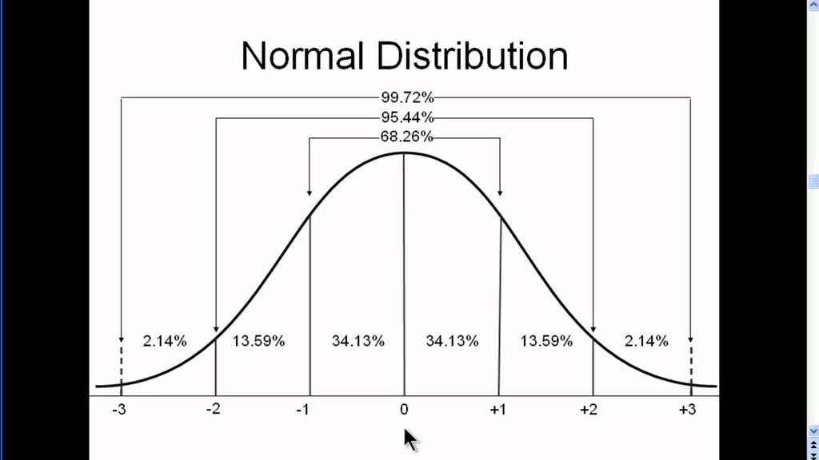

# ##Observation: The normal distribution is commonly associated with the 68-95-99.7 rule which you can see in the image above. Example of Normal Distribution: 1. Heights of people. 2. Measurement errors. 3. Blood pressure. 4. Points on a test. 5. IQ scores. 6. Salaries Properties of a normal distribution: 1. The mean, mode and median are all equal. 2. The curve is symmetric at the center (i.e. around the mean, μ). 3. Exactly half of the values are to the left of center and exactly half the values are to the right. 4. The total area under the curve is 1. The empirical rule tells you what percentage of your data falls within a certain number of standard deviations from the mean: • 68% of the data falls within one standard deviation of the mean. • 95% of the data falls within two standard deviations of the mean. • 99.7% of the data falls within three standard deviations of the mean.

```python
#Now we have a mean and stander deviation of Age feature now we find the Far end values or extreme value
#where extreme values means the values after 3rd stander deviation
#so extreme = (Mean of Age Feature + ( 3 * stander deviation of Age Feature)

extreme=df_m.Age.mean()+3*df_m.Age.std()
print(extreme)
```

```
73.27860964406094
```

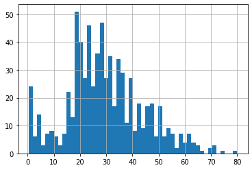

```python
df_m.Age.hist(bins=50)
```

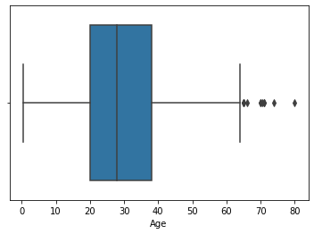

```python
import seaborn as sns
sns.boxplot('Age',data=df_m)
```

# Observation:

```
from both plots we can see that extrame values are between ~ 70 to 80 in other word it is a outliers
```

```python
def impute_nan(df_m,variable,extreme):
    df_m[variable+"_end_distribution"]=df_m[variable].fillna(extreme)
    df_m[variable+"_Median"]= df_m[variable].fillna(df_m[variable].median())#Age Nan value is replaced by Median
```

```python
impute_nan(df_m,'Age',extreme)
```

```python
df_m.head(6)
```

|  | Survived | Age | Fare | Age_end_distribution | Age_Median |
| --- | --- | --- | --- | --- | --- |
| 0 | 0 | 22.0 | 7.2500 | 22.00000 | 22.0 |
| 1 | 1 | 38.0 | 71.2833 | 38.00000 | 38.0 |
| 2 | 1 | 26.0 | 7.9250 | 26.00000 | 26.0 |
| 3 | 1 | 35.0 | 53.1000 | 35.00000 | 35.0 |
| 4 | 0 | 35.0 | 8.0500 | 35.00000 | 35.0 |
| 5 | 0 | NaN | 8.4583 | 73.27861 | 28.0 |

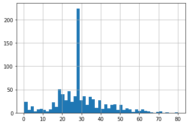

```python
df_m['Age_Median'].hist(bins=50)#Replaced the nan value with Median Value
```

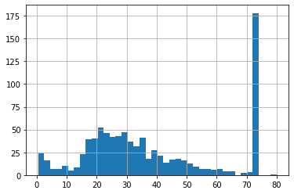

```python
df_m['Age_end_distribution'].hist(bins=40)#Replaced nan with ouliers
```

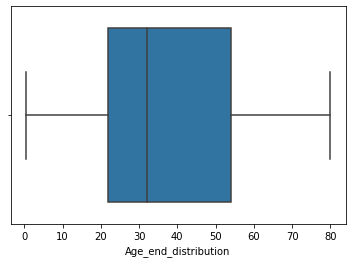

```python
sns.boxplot('Age_end_distribution',data=df_m)#There is no oulier here
```

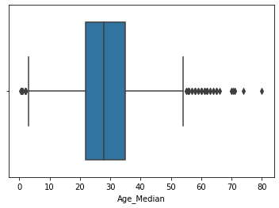

```python
sns.boxplot('Age_Median',data=df_m)
```

```python
import matplotlib.pyplot as plt
from matplotlib.pyplot import figure
%matplotlib inline
fig = plt.figure()
fig.set_dpi(800)
fig.set_size_inches(18.5, 12.5,forward=True)

ax_1=fig.add_subplot(111)

df_m['Age'].plot(kind='kde', ax=ax_1,color="blue")

df_m['Age_Median'].plot(kind='kde', ax=ax_1, color="yellow")



df_m['Age_end_distribution'].plot(kind='kde', ax=ax_1, color='red')
lines, labels = ax_1.get_legend_handles_labels()
ax_1.legend(lines, labels, loc='best')
```

[figure not shown]

# Observation:

# Advantages:

```
1-Easy to implement
2-Capture the importance of missing((if one suspects the missing data is valuable)
```

# Disadvantages:

1-Distorts the original distribution of data

2- performing this action may distort the variable, mask predictive power if missingness is not important,

3-Hide true outliers if the missing data is large or create an unintended outlier if N/As are small.